## INVESTING A DATASET

### GIVEN DATASET(TITANIC DATASET)

The Titanic ship resulting in the deaths of most of its passengers and crew. In this project we will explore a subset of the Titanic passenger manifest to determine which features best predict whether someone survived or did not survive.

### Questions related to Titanic Dataset:

1. What factors made people more likely to survive?
2. Does the surviving depend on the age or sex of the people?

```python
import numpy as np
import matplotlib.pyplot as plot
import pandas as pds
from pandas import DataFrame
import seaborn as sb
```

The data from the csv file are read.

```python
Gdata = pds.read_csv("titanic-data.csv")
```

The number of rows and columns are identified using the below line.

```python
Gdata.shape
```

```
(891, 12)
```

The total details of the table are,

```python
Gdata.head()
```

|  | PassengerId | Survived | Pclass | Name | Sex | Age | SibSp | Parch | Ticket | Fare | Cabin | Embarked |
| --- | --- | --- | --- | --- | --- | --- | --- | --- | --- | --- | --- | --- |
| 0 | 1 | 0 | 3 | Braund, Mr. Owen Harris | male | 22.0 | 1 | 0 | A/5 21171 | 7.2500 | NaN | S |
| 1 | 2 | 1 | 1 | Cumings, Mrs. John Bradley (Florence Briggs Th... | female | 38.0 | 1 | 0 | PC 17599 | 71.2833 | C85 | C |
| 2 | 3 | 1 | 3 | Heikkinen, Miss. Laina | female | 26.0 | 0 | 0 | STON/O2. 3101282 | 7.9250 | NaN | S |
| 3 | 4 | 1 | 1 | Futrelle, Mrs. Jacques Heath (Lily May Peel) | female | 35.0 | 1 | 0 | 113803 | 53.1000 | C123 | S |
| 4 | 5 | 0 | 3 | Allen, Mr. William Henry | male | 35.0 | 0 | 0 | 373450 | 8.0500 | NaN | S |

From this table we can select only the particular details which we needed

```python
Gdata.head().groupby('Survived')['Sex'].describe()
```

| Survived | count | unique | top | freq |
| --- | --- | --- | --- | --- |
| 0 | 2 | 1 | male | 2 |
| 1 | 3 | 1 | female | 3 |

## Data Wrangling Phase

The Ages of 177 people are missing from 891 members in the dataset. This data should be filtered before Analyzing. So,the original data and the values for remaining dataset is analyzed by removing the missing data. This is done by filtering the data by using dropna() function. The dataset with values are taken and the ones without the values are ignored. This phase is called Data Wrangling Phase.

```python
Fdata = Gdata.loc[:,['Survived','Pclass','Sex','Age','SibSp']]
Udata = Fdata.dropna()
```

```python
Udata.shape
```

```
(714, 5)
```

```python
Udata.corr()
```

|  | Survived | Pclass | Age | SibSp |
| --- | --- | --- | --- | --- |
| Survived | 1.000000 | -0.359653 | -0.077221 | -0.017358 |
| Pclass | -0.359653 | 1.000000 | -0.369226 | 0.067247 |
| Age | -0.077221 | -0.369226 | 1.000000 | -0.308247 |
| SibSp | -0.017358 | 0.067247 | -0.308247 | 1.000000 |

```python
Gdata.groupby('Survived')['Sex'].describe()
```

| Survived | count | unique | top | freq |
| --- | --- | --- | --- | --- |
| 0 | 549 | 2 | male | 468 |
| 1 | 342 | 2 | female | 233 |

```python
def bar_graph(x_axis, y_axis, x_desc, y_desc, g_data, title):
    sb.barplot(x = x_axis, y = y_axis, data = g_data)
    plot.title(title)
    plot.xlabel(x_desc)
    plot.ylabel(y_desc)
    plot.show()
```

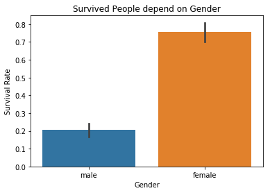

```python
bar_graph('Sex', 'Survived', 'Gender', 'Survival Rate', Udata, 'Survived People depend on Gender')
```

This bar graph shows the female paasengers and crew are survived more compare with male passengers.

Next, we can compare with different age gropus.

```python
Speople = Udata[Udata['Survived'] == 1]
Dpeople = Udata[Udata['Survived'] == 0]
```

```python
def plot_histogram(ages, x, y):
    plot.xlabel(x)
    plot.ylabel(y)
    plot.hist(ages)
    plot.show()
```

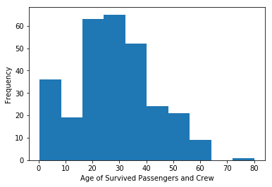

```python
plot_histogram(Speople['Age'], 'Age of Survived Passengers and Crew', 'Frequency')
```

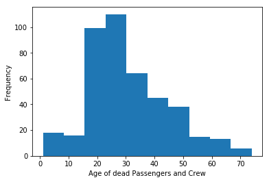

```python
plot_histogram(Dpeople['Age'], 'Age of dead Passengers and Crew', 'Frequency')
```

```python
Udata.corr()
```

|  | Survived | Pclass | Age | SibSp |
| --- | --- | --- | --- | --- |
| Survived | 1.000000 | -0.359653 | -0.077221 | -0.017358 |
| Pclass | -0.359653 | 1.000000 | -0.369226 | 0.067247 |
| Age | -0.077221 | -0.369226 | 1.000000 | -0.308247 |
| SibSp | -0.017358 | 0.067247 | -0.308247 | 1.000000 |

```python
Udata.groupby('Sex')['Survived'].mean()
```

```
Sex
female    0.754789
male      0.205298
Name: Survived, dtype: float64
```

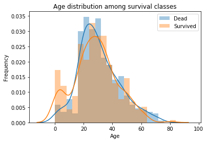

```python
age_bins = np.arange(0, 100, 4)
sb.distplot(Gdata.loc[(Gdata['Survived']==0) & (~Gdata['Age'].isnull()),'Age'], bins=age_bins)
sb.distplot(Gdata.loc[(Gdata['Survived']==1) & (~Gdata['Age'].isnull()),'Age'], bins=age_bins)
plot.title('Age distribution among survival classes')
plot.ylabel('Frequency')
plot.legend(['Dead', 'Survived']);
plot.show()
```

```python
Gdata.isnull().sum()
```

```
PassengerId      0
Survived         0
Pclass           0
Name             0
Sex              0
Age            177
SibSp            0
Parch            0
Ticket           0
Fare             0
Cabin          687
Embarked         2
dtype: int64
```

### To increase the survivability, some predictions are,

If the incident was happened in day time then number of survived peoples might be increased. There may ba other questions like, would there be higher chance of survivng if the hull of the ship had been stronger, would there be a higher chance of survival, or if the cabins were open, would it increase the chances of survival.

## CONCLUSION

```python
from scipy import stats as st
st.ttest_ind(Speople['Age'], Dpeople['Age'])
```

```
Ttest_indResult(statistic=-2.0666869462538102, pvalue=0.039124654013482488)
```

The disadvantage of this dataset is that there are several missing values in the table. The missing values affect the Analysis of the Data. Since the data is missing, the computations done above cannot be said accurate.